# Workshop Example

Robert Buchkowski

2026-03-04

## Rationale

This is a small example of how I proposed that we proceed with our analysis. I am showing just a simple example of one possible indirect effect, but the goal is to be more comprehensive. I am using the Millennial Model as an example.

Here is the example of earthworms affecting aggregation rate of POM into soil aggregates. Our literature search suggests that earthworms might increase this rate by somewhere between 25 and 75% (I just made this up for this example).

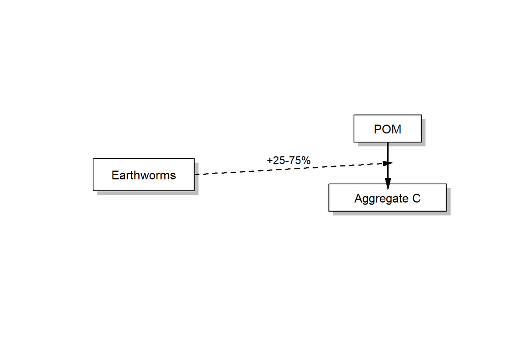

## Lever

In the Millennial Model, the aggregation rate is controlled by the parameter `k_pa`, so this is the one that we think earthworms will modify. The first, basic option is to test how much changing this parameter might influence carbon distribution in the soil pools.